# Beta-binomial prior for model dimension

Ville Karhunen

26.01.2023

[figure not shown]

Finimom employs a beta-binomial prior for model dimension $d$:

$$\mathbb{P}(d = k | a, b) = \binom{p}{k}\frac{B(a + k, p - k + b)}{B(a,
b)}, \quad a, b > 0, \quad d = 1, \dots, K,$$

where $p$ is the number of variants and $K$ the maximum model size. The priors of this form with $a = 1$ and $b = p^u$ with $u > 1$, are discussed in Castillo and van der Vaart (2012) and in Castillo et al. (2015). The parameter $u$ here controls the amount of prior density for smaller models, with larger values of $u$ giving more prior mass to smaller models.

Using a linkage disequilibrium (LD) matrix from an external dataset tend to increase the false positive rate. In our formulation, parameter $u$ provides a flexible way to adjust for this. The default values are $u = 1.5$ when using in-sample LD matrix, and $u = 1.75$ when using out-of-sample LD matrix.

We demonstrate the prior for model dimension using the example dataset:

```r
library(finimom)

(p <- length(exampledata$betahat))
```

```
#> [1] 363
```

```r
maxsize <- 10

a <- 1
u <- 1.5

val <- exp(sapply(seq_len(maxsize), dbb, p = p, a = a, b = p^u))
(val <- val/sum(val))
```

```
#>  [1] 9.502616e-01 4.727099e-02 2.345333e-03 1.160564e-04 5.727772e-06
#>  [6] 2.819359e-07 1.384076e-08 6.776590e-10 3.309028e-11 1.611478e-12
```

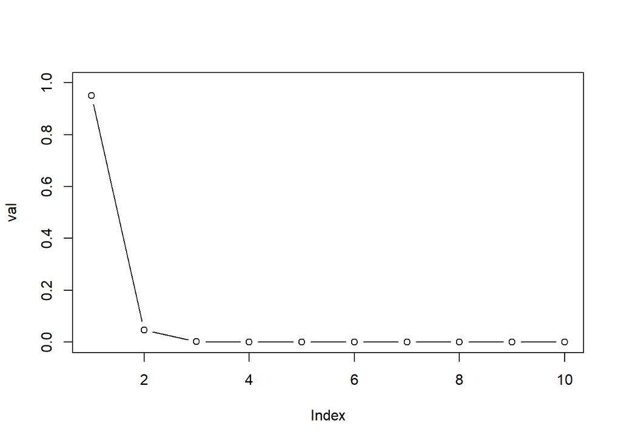

```r
plot(val, type = "b", ylim = c(0, 1))
```

And for different values of $u$:

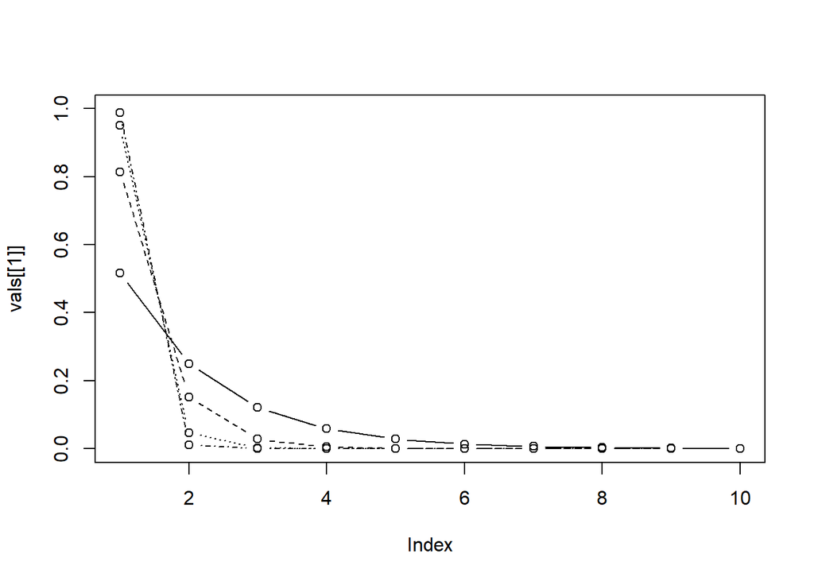

```r
us <- c(1.01, 1.25, 1.5, 1.75)

vals <- lapply(us, function(u){
  b <- p^u
  out <- exp(sapply(1:10, dbb, a = a, p = p, b = b))
  out <- out/sum(out)
})

plot(vals[[1]], type = "b", ylim = c(0, 1))
invisible(lapply(2:4, function(i) lines(vals[[i]], type = "b", lty = i)))
```

The same on a log scale:

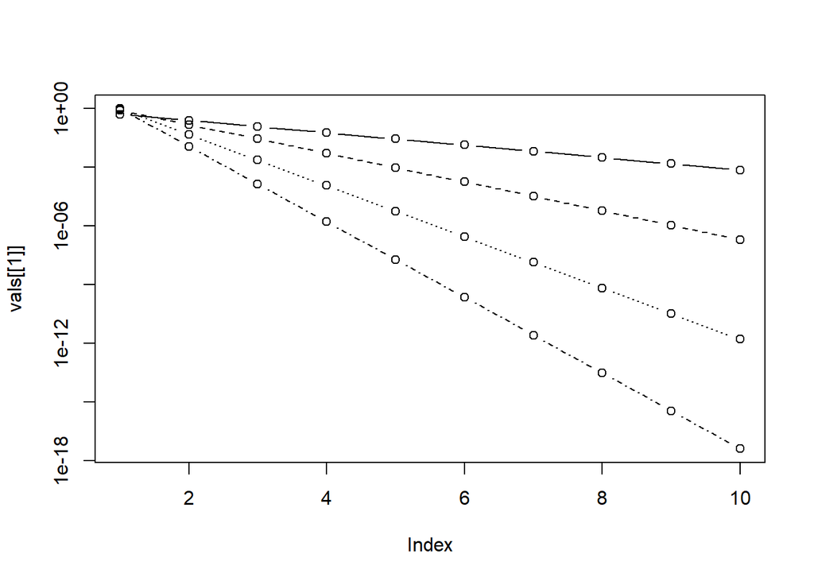

```r
plot(vals[[1]], type = "b", log = "y", ylim = range(unlist(vals)))
invisible(lapply(2:4, function(i) lines(vals[[i]], type = "b", lty = i)))
```

# References

Castillo and van der Vaart (2012). Needles and Straw in a Haystack: Posterior concentration for possibly sparse sequences. *The Annals of Statistics*.

Castillo et al. (2015). Bayesian linear regression with sparse priors. *The Annals of Statistics*.